# Earth - Like Exoplanet Composition and Interior Similarity

Author

Albina Osipina

## Specific Question

Which confirmed exoplanets meet the selected Earth - like radius and mass boundaries, what proportion appear rocky rather than volatile-rich, and which rocky - like candidates have interiors most similar to Earth?

## Analytical Approach

The analysis used planetary radius, mass, density, and mass provenance from the NASA Exoplanet Archive.

These project-defined boundaries create a broad screening group around Earth’s radius and mass. They are analytical selection criteria rather than a universal scientific definition of an Earth-like planet.

Planets with masses derived from an M - R relationship were excluded to avoid circular classification. The remaining planets were classified by comparing their observed masses with the rocky and volatile-rich relationships from Otegi et al. (2020). Rocky - like candidates were then ranked using an Interior ESI based on radius and density. This score measures physical similarity to Earth’s interior, not habitability.

## Data Acquisition and Processing

The NASA Planetary Systems Composite Parameters data were downloaded through the NASA Exoplanet Archive API using shared/download_nasa_data.R. The shared pipeline then cleaned and validated the data using shared/prepare_analysis_data.R and calculated the project-wide ESI values using shared/esi/calculate_esi.R. These scripts produce the processed esi_results.csv file used in this analysis.

```r
# Run from the repository root to rebuild the processed data
source("shared/download_nasa_data.R")
source("shared/prepare_analysis_data.R")
source("shared/esi/calculate_esi.R")
```

```r
# Import the processed dataset used in this report
esi_results <- read.csv(
  "../../data/processed/esi_results.csv",
  stringsAsFactors = FALSE
)

required_columns <- c(
  "pl_name",
  "pl_rade",
  "pl_bmasse",
  "pl_dens",
  "pl_bmassprov"
)

stopifnot(
  all(required_columns %in% names(esi_results))
)
```

## Candidate Selection

```r
# Select planets within the Earth-like boundaries
earth_candidates <- esi_results[
  !is.na(esi_results$pl_rade) &
    !is.na(esi_results$pl_bmasse) &
    esi_results$pl_rade > 0.5 &
    esi_results$pl_rade <= 1.5 &
    esi_results$pl_bmasse > 0.1 &
    esi_results$pl_bmasse <= 3,
]

candidate_count <- nrow(earth_candidates)
```

The selection retained 913 of the 6,366 confirmed exoplanets. These planets satisfied both the radius and mass conditions and formed the initial candidate sample.

## Interior Earth Similarity Index

Interior ESI compares each planet’s radius and density with Earth. Earth’s reference values were set to 1 Earth radius and 5.514 g/cm³. The component weights were 0.57 for radius and 1.07 for density, following Schulze - Makuch et al. (2011). Scores closer to 1 indicate greater interior similarity to Earth.

```r
# Calculate the radius component
earth_candidates$radius_score <- (
  1 - abs(
    (earth_candidates$pl_rade - 1) /
      (earth_candidates$pl_rade + 1)
  )
)^0.57

# Calculate the density component
earth_candidates$density_score <- (
  1 - abs(
    (earth_candidates$pl_dens - 5.514) /
      (earth_candidates$pl_dens + 5.514)
  )
)^1.07

# Combine both components
earth_candidates$interior_esi <- sqrt(
  earth_candidates$radius_score *
    earth_candidates$density_score
)

interior_count <- sum(
  !is.na(earth_candidates$interior_esi)
)
```

Interior ESI was calculated only when both radius and density were available. The score measures similarity in selected physical characteristics and should not be interpreted as evidence of habitability.

## Mass Provenance Filter

The source of each reported mass was reviewed before composition classification. Planets whose masses were derived from an M - R relationship were excluded because applying another mass-radius relationship to those values would create circular reasoning.

```r
# Review how planet masses were obtained
mass_provenance <- table(
  earth_candidates$pl_bmassprov,
  useNA = "ifany"
)

# Count masses derived from a mass - radius relationship
mr_count <- sum(
  earth_candidates$pl_bmassprov == "M-R relationship",
  na.rm = TRUE
)

empirical_candidates <- earth_candidates[
  !is.na(earth_candidates$pl_bmassprov) &
    earth_candidates$pl_bmassprov != "M-R relationship",
]

empirical_count <- nrow(empirical_candidates)
```

Of the 913 initial candidates, 767 (84.0%) had masses derived from an M–R relationship and were excluded. The remaining 146 planets formed the non M–R derived analysis sample used for composition classification.

## Composition Classification

For each planet, expected mass was calculated from the rocky and volatile - rich mass - radius relationships reported by Otegi et al. (2020):

- Rocky: (M = 0.90R^{3.45})
- Volatile-rich: (M = 1.74R^{1.58})

The observed mass was compared with both predictions using absolute log - ratio differences. This measures proportional rather than absolute error. Each planet was assigned to the relationship with the smaller difference.

```r
# Expected mass from the rocky relationship
empirical_candidates$rocky_expected_mass <-
  0.90 * empirical_candidates$pl_rade^3.45

# Expected mass from the volatile - rich relationship
empirical_candidates$volatile_expected_mass <-
  1.74 * empirical_candidates$pl_rade^1.58

# Calculate proportional differences from both relationships
empirical_candidates$rocky_difference <- abs(
  log(
    empirical_candidates$pl_bmasse /
      empirical_candidates$rocky_expected_mass
  )
)

empirical_candidates$volatile_difference <- abs(
  log(
    empirical_candidates$pl_bmasse /
      empirical_candidates$volatile_expected_mass
  )
)

# Assign each planet to the closer relationship
empirical_candidates$composition <- ifelse(
  empirical_candidates$rocky_difference <=
    empirical_candidates$volatile_difference,
  "Rocky-like",
  "Volatile-rich-like"
)

composition_counts <- table(
  empirical_candidates$composition
)
```

Of the 146 non M - R derived candidates, 99 (67.8%) were classified as rocky - like and 47 (32.2%) as volatile - rich - like. Therefore, satisfying the selected radius and mass boundaries did not guarantee a rocky composition.

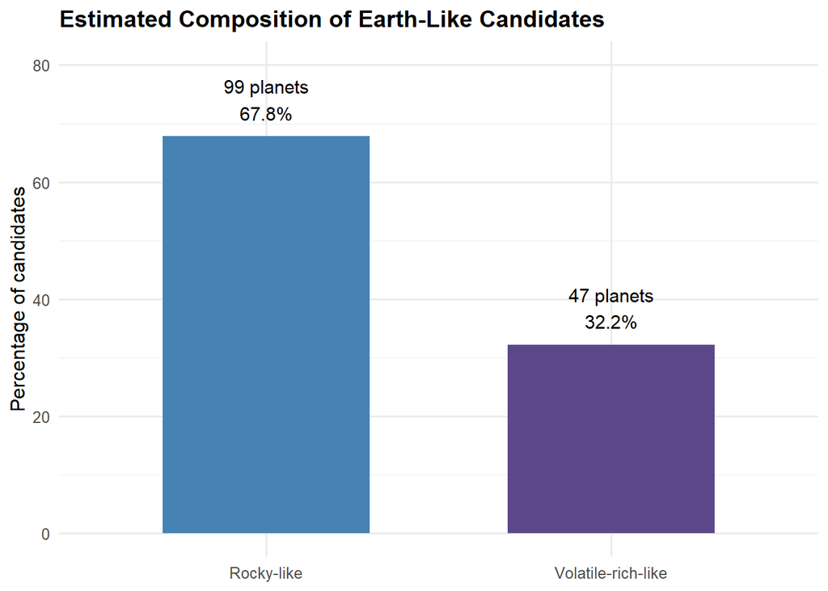

Composition classification of the 146 non-M-R-derived candidates.

```r
library(ggplot2)

# Prepare the classification summary
composition_summary <- data.frame(
  composition = names(composition_counts),
  count = as.numeric(composition_counts)
)

composition_summary$percent <- round(
  composition_summary$count /
    sum(composition_summary$count) * 100,
  1
)

# Plot the composition results
composition_plot <- ggplot(
  composition_summary,
  aes(
    x = composition,
    y = percent,
    fill = composition
  )
) +
  geom_col(width = 0.6) +
  geom_text(
    aes(
      label = paste0(
        count,
        " planets\n",
        percent,
        "%"
      )
    ),
    vjust = -0.4,
    size = 4
  ) +
  scale_fill_manual(
    values = c(
      "Rocky-like" = "steelblue",
      "Volatile-rich-like" = "mediumpurple4"
    )
  ) +
  labs(
    title = "Estimated Composition of Earth-Like Candidates",
    x = NULL,
    y = "Percentage of candidates"
  ) +
  ylim(0, 80) +
  theme_minimal(base_size = 12) +
  theme(
    legend.position = "none",
    plot.title = element_text(face = "bold")
  )

composition_plot
```

## Ranking Rocky - Like Candidates

The 99 rocky - like planets were ranked from highest to lowest Interior ESI. The ranking identifies planets with radius and density most similar to Earth within the analysis sample.

```r
# Keep and rank rocky - like candidates
rocky_ranked <- empirical_candidates[
  empirical_candidates$composition == "Rocky-like" &
    !is.na(empirical_candidates$interior_esi),
]

rocky_ranked <- rocky_ranked[
  order(
    rocky_ranked$interior_esi,
    decreasing = TRUE
  ),
  c(
    "pl_name",
    "pl_rade",
    "pl_bmasse",
    "pl_dens",
    "pl_bmassprov",
    "interior_esi",
    "composition"
  )
]

# Prepare the five highest - ranked candidates for display
top_5_table <- head(rocky_ranked, 5)

top_5_table$interior_esi <- round(
  top_5_table$interior_esi,
  3
)

top_5_table <- top_5_table[
  c(
    "pl_name",
    "pl_rade",
    "pl_bmasse",
    "pl_dens",
    "interior_esi"
  )
]

names(top_5_table) <- c(
  "Planet",
  "Radius",
  "Mass",
  "Density",
  "Interior ESI"
)

knitr::kable(
  top_5_table,
  caption = "Five highest-ranked rocky-like candidates",
  digits = 3,
  row.names = FALSE
)
```

Five highest-ranked rocky-like candidates

| Planet | Radius | Mass | Density | Interior ESI |
| --- | --- | --- | --- | --- |
| Proxima Cen b | 1.02 | 1.055 | 5.46 | 0.995 |
| YZ Cet d | 1.03 | 1.090 | 5.48 | 0.994 |
| AU Mic d | 1.02 | 1.053 | 5.45 | 0.994 |
| Teegarden’s Star c | 1.02 | 1.050 | 5.44 | 0.994 |
| Teegarden’s Star b | 1.05 | 1.160 | 5.51 | 0.993 |

Proxima Centauri b had the highest Interior ESI at 0.995. YZ Ceti d, AU Microscopii d, Teegarden’s Star c, and Teegarden’s Star b followed closely. Because the scores are very similar, the ranking should be interpreted as an approximate prioritization rather than a definitive ordering.

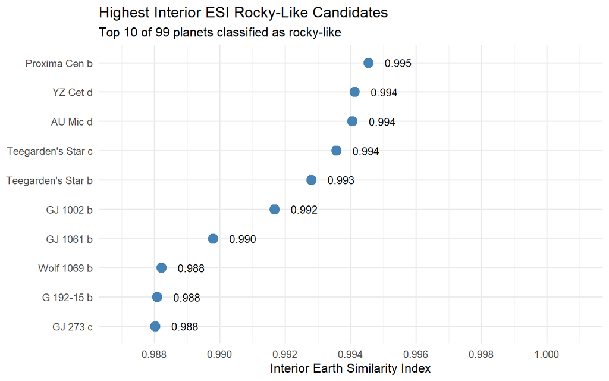

Ten rocky-like candidates with the highest Interior ESI.

```r
top_10_rocky <- head(rocky_ranked, 10)

top_10_rocky$pl_name <- factor(
  top_10_rocky$pl_name,
  levels = rev(top_10_rocky$pl_name)
)

ggplot(
  top_10_rocky,
  aes(x = interior_esi, y = pl_name)
) +
  geom_point(color = "steelblue", size = 4) +
  geom_text(
    aes(label = sprintf("%.3f", interior_esi)),
    nudge_x = 0.0005,
    hjust = 0,
    size = 3.5
  ) +
  scale_x_continuous(
    limits = c(0.987, 1.001),
    breaks = seq(0.988, 1.000, 0.002)
  ) +
  labs(
    title = "Highest Interior ESI Rocky-Like Candidates",
    subtitle = "Top 10 of 99 planets classified as rocky-like",
    x = "Interior Earth Similarity Index",
    y = NULL
  ) +
  theme_minimal(base_size = 12)
```

The leading candidates have very similar Interior ESI scores. Proxima Centauri b ranks first, but the small differences among the top planets indicate that the ranking should be interpreted as approximate rather than definitive.

## Data Quality and Limitations

- **Mass provenance:** We excluded 767 planets whose masses were derived from mass - radius relationships to avoid circular classification. This reduced the analysis sample to 146 non M - R derived planets.
- **Measurement uncertainty:** Planetary mass, radius, and density contain uncertainty that was not incorporated into the classifications. Planets near the boundary could change categories.
- **Minimum-mass estimates:** Some reported values are minimum-mass estimates rather than true planetary masses, which may affect their classification.
- **Model limitations:** The Otegi relationships are empirical approximations and do not directly confirm a planet’s composition.
- **ESI interpretation:** Interior ESI measures similarity in radius and density only. It does not account for atmosphere, temperature, liquid water, stellar activity, or overall habitability.

## Conclusion

Of the 6,366 confirmed exoplanets, 913 met the selected Earth - like radius and mass conditions. After excluding masses derived from mass - radius relationships, 146 planets remained for composition analysis. Of these, 99 were classified as rocky - like and 47 as volatile - rich - like.

Proxima Centauri b had the highest Interior ESI. However, the results show that Earth - like radius and mass alone do not guarantee a rocky composition, and a high Interior ESI should not be interpreted as evidence of habitability.

## References

NASA Exoplanet Archive. (2026). *Planetary Systems Composite Parameters*. California Institute of Technology. https://exoplanetarchive.ipac.caltech.edu/

Otegi, J. F., Bouchy, F., & Helled, R. (2020). Revisited mass-radius relations for exoplanets below 120 Earth masses. *Astronomy & Astrophysics, 634*, A43. https://doi.org/10.1051/0004-6361/201936482

Schulze-Makuch, D., et al. (2011). A two-tiered approach to assessing the habitability of exoplanets. *Astrobiology, 11*(10), 1041–1052. https://doi.org/10.1089/ast.2010.0592